# 单表数据处理

例3 查看具有最长平均延误时间的航班

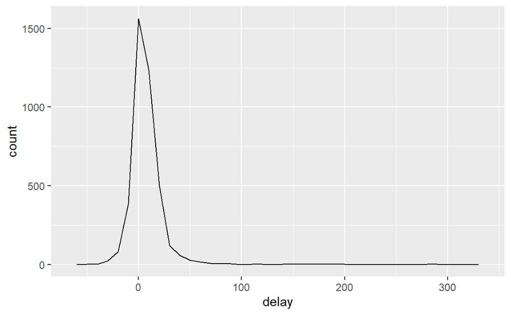

```r
# 通过尾号（tailnum）对航班进行分组识别
not_cancelled %>%
  group_by(tailnum) %>%
  summarize(delay = mean(arr_delay)) %>%
  ggplot(mapping = aes(x = delay)) +
  geom_freqpoly(binwidth = 10)
```

有些航班的平均延误时间长达300分钟，这是怎么回事呢？

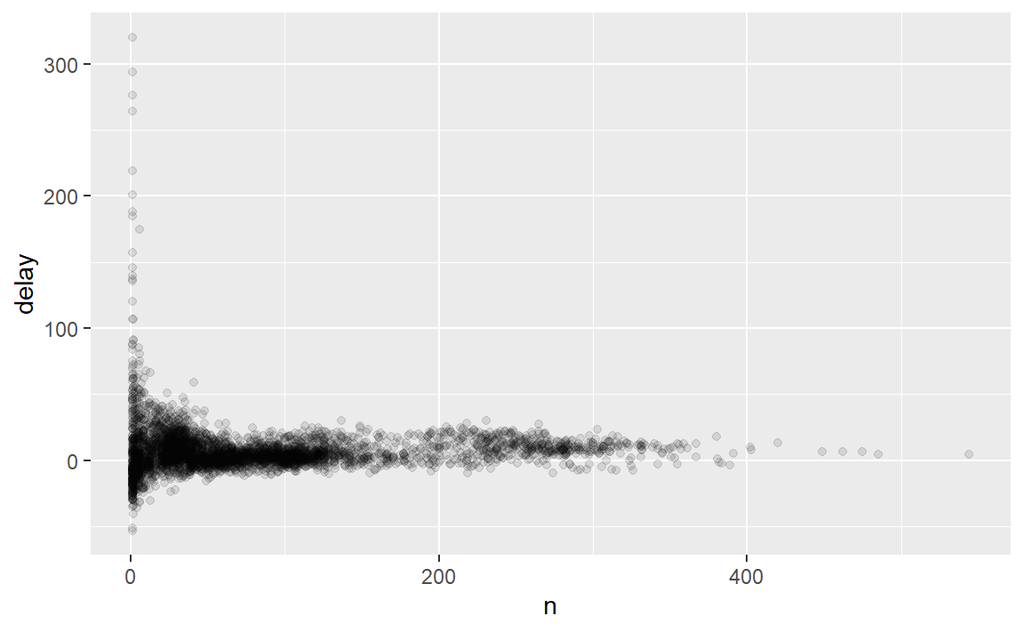

```r
# 作航班架次数量和平均延误时间的散点图
not_cancelled %>%
  group_by(tailnum) %>%
  summarize(delay = mean(arr_delay), n = n()) %>%
  ggplot(mapping = aes(x = n, y = delay)) +
  geom_point(alpha = 0.1)
```

由图可见，当航班数量非常少时，平均延误时间的变动特别大。

注：这张图的形状非常能够说明问题：当绘制均值（或其他摘要统计量）和分组规模的关系时，总能看到随着样本量的增加，变动在不断减小。因此，查看此类图形时，**通常应该筛选掉那些观测数量非常少的分组，这样就可以避免受到特别小的分组中的极端变动的影响，进而更好地发现数据模式**。

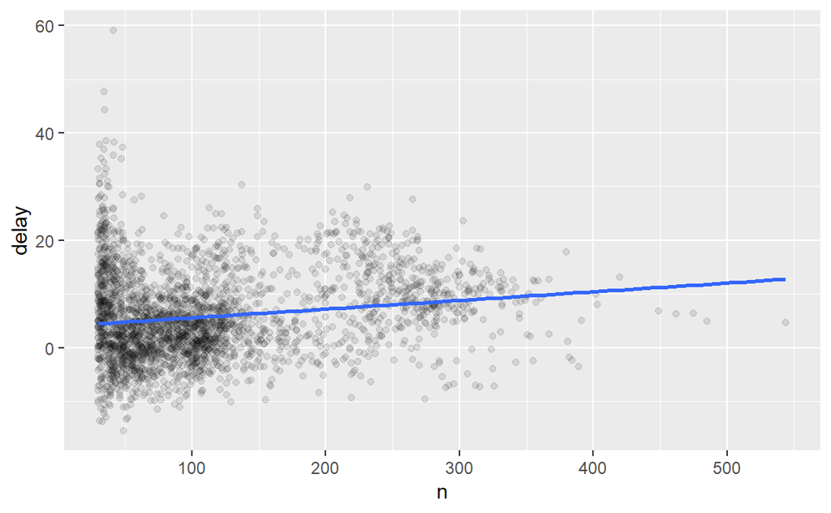

```r
# 作去掉小样本后，航班架次数量和平均延误时间的散点图
not_cancelled %>%
  group_by(tailnum) %>%
  summarize(delay = mean(arr_delay), n = n()) %>%
  filter(n >= 30) %>%
  ggplot(mapping = aes(x = n, y = delay)) +
  geom_point(alpha = 0.1) +
  geom_smooth(method = 'lm',se = FALSE)
```

这时我们发现，平均延误时间大多在20分钟以下；飞行架次在30以上的航班，平均延误时间最长的也只有60分钟。

例4 棒球击球手的安打率与击球次数之间的关系（能力与出场机会的关系）

```r
# 棒球比赛数据，转换成tibble使输出更美观
batting <- as_tibble(Lahman::Batting)

# 根据球员ID分组统计，总击打数ab和安打率ba（安打数/击打数）
# 分组统计后包含playerID, ab, ba变量的新数据框为batters
batters <- batting %>%
  group_by(playerID) %>%
  summarize(ba = sum(H, na.rm = TRUE)/sum(AB, na.rm = TRUE),
            ab = sum(AB, na.rm = TRUE))

# 按安打率排名，发现位次最靠前的是一些总击打数几乎为零、
# 靠好运气获得极高安打率的球员——而这并不表明能力强。
batters %>% arrange(desc(ba))
```

```
#> # A tibble: 19,898 x 3
#>    playerID     ba    ab
#>    <chr>     <dbl> <int>
#>  1 abramge01     1     1
#>  2 alanirj01     1     1
#>  3 alberan01     1     1
#>  4 banisje01     1     1
#>  5 bartocl01     1     1
#>  6 bassdo01      1     1
#>  7 birasst01     1     2
#>  8 bruneju01     1     1
#>  9 burnscb01     1     1
#> 10 cammaer01     1     1
#> # ... with 19,888 more rows
```

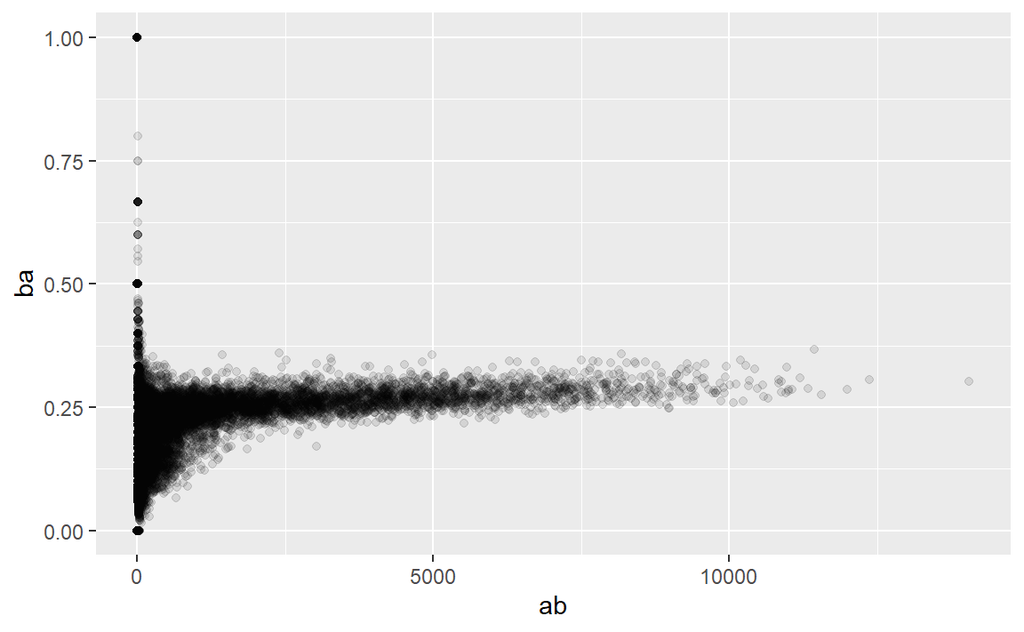

```r
batters %>% ggplot(mapping = aes(x = ab, y = ba)) +
  geom_point(alpha = 0.1)
```

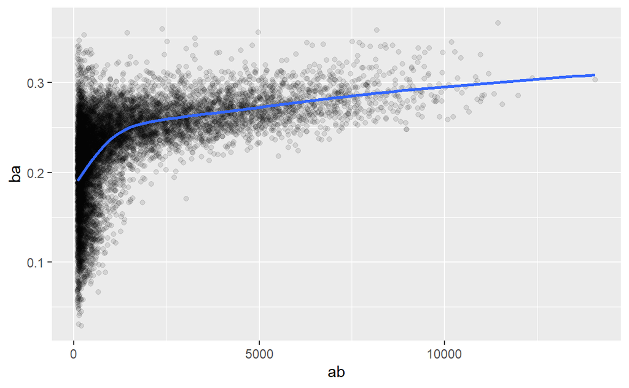

```r
# 忽略小样本，绘制安打率~击打数散点图，发现安打率基本小于35%
# 正相关关系，说明安打率较高的球员击打数较多（出场机会多）
# 由图可见，拥有20%以上的安打率，才有机会成为球队主力
batters %>% filter(ab > 100) %>%
  ggplot(mapping = aes(x = ab, y = ba)) +
  geom_point(alpha = 0.1) + geom_smooth(se = FALSE)
```

```r
# 从N.Y.到其他机场飞行距离的标准差
not_cancelled %>%
  group_by(dest) %>%
  summarize(distance_sd = sd(distance)) %>%
  arrange(desc(distance_sd))
```

```
#> # A tibble: 104 x 2
#>    dest  distance_sd
#>    <chr>       <dbl>
#>  1 EGE         10.5
#>  2 SAN         10.4
#>  3 SFO         10.2
#>  4 HNL         10.0
#>  5 SEA          9.98
#>  6 LAS          9.91
#>  7 PDX          9.87
#>  8 PHX          9.86
#>  9 LAX          9.66
#> 10 IND          9.46
#> # ... with 94 more rows
```

```r
# 每天最早和最晚航班的出发时间
not_cancelled %>% group_by(year, month, day) %>%
  summarize(first = min(dep_time), last = max(dep_time))
```

```
#> # A tibble: 365 x 5
#> # Groups:   year, month [12]
#>     year month   day first  last
#>    <int> <int> <int> <int> <int>
#>  1  2013     1     1   517  2356
#>  2  2013     1     2    42  2354
#>  3  2013     1     3    32  2349
#>  4  2013     1     4    25  2358
#>  5  2013     1     5    14  2357
#>  6  2013     1     6    16  2355
#>  7  2013     1     7    49  2359
#>  8  2013     1     8   454  2351
#>  9  2013     1     9     2  2252
#> 10  2013     1    10     3  2320
#> # ... with 355 more rows
```

```r
# 找出每天最早和最晚出发的航班
# min_rank(x)可以返回一个序列各元素的升序位置向量
# min_rank(desc(x))返回降序位置向量
# 对出发时间排序后，用range()取出最大值和最小值
# 再用filter()取出每天出发最早和最晚的航班
not_cancelled %>% group_by(year, month, day) %>%
  mutate(r = min_rank(desc(dep_time))) %>%
  filter(r %in% range(r))
```

```
#> # A tibble: 770 x 20
#> # Groups:   year, month, day [365]
#>     year month   day dep_time sched_dep_time dep_delay arr_time sched_arr_time
#>    <int> <int> <int>    <int>          <int>     <dbl>    <int>          <int>
#>  1  2013     1     1      517            515         2      830            819
#>  2  2013     1     1     2356           2359        -3      425            437
#>  3  2013     1     2       42           2359        43      518            442
#>  4  2013     1     2     2354           2359        -5      413            437
#>  5  2013     1     3       32           2359        33      504            442
#>  6  2013     1     3     2349           2359       -10      434            445
#>  7  2013     1     4       25           2359        26      505            442
#>  8  2013     1     4     2358           2359        -1      429            437
#>  9  2013     1     4     2358           2359        -1      436            445
#> 10  2013     1     5       14           2359        15      503            445
#> # ... with 760 more rows, and 12 more variables: arr_delay <dbl>,
#> #   carrier <chr>, flight <int>, tailnum <chr>, origin <chr>, dest <chr>,
#> #   air_time <dbl>, distance <dbl>, hour <dbl>, minute <dbl>, time_hour <dttm>,
#> #   r <int>
```

```r
# 纽约至哪个目的地的航线有最多的航空公司运营
# n_distinct()函数统计唯一值的数量
not_cancelled %>%
  group_by(dest) %>%
  summarize(carriers = n_distinct(carrier)) %>%
  arrange(desc(carriers))
```

```
#> # A tibble: 104 x 2
#>    dest  carriers
#>    <chr>    <int>
#>  1 ATL          7
#>  2 BOS          7
#>  3 CLT          7
#>  4 ORD          7
#>  5 TPA          7
#>  6 AUS          6
#>  7 DCA          6
#>  8 DTW          6
#>  9 IAD          6
#> 10 MSP          6
#> # ... with 94 more rows
```

```r
# 纽约出发的每条航线有多少个航班
not_cancelled %>% count(dest)
```

```
#> # A tibble: 104 x 2
#>    dest      n
#>    <chr> <int>
#>  1 ABQ     254
#>  2 ACK     264
#>  3 ALB     418
#>  4 ANC       8
#>  5 ATL   16837
#>  6 AUS    2411
#>  7 AVL     261
#>  8 BDL     412
#>  9 BGR     358
#> 10 BHM     269
#> # ... with 94 more rows
```

```r
# 加权记数，计算每个航班的总飞行距离
not_cancelled %>% count(tailnum, wt = distance)
```

```
#> # A tibble: 4,037 x 2
#>    tailnum      n
#>    <chr>    <dbl>
#>  1 D942DN    3418
#>  2 N0EGMQ  239143
#>  3 N10156  109664
#>  4 N102UW   25722
#>  5 N103US   24619
#>  6 N104UW   24616
#>  7 N10575  139903
#>  8 N105UW   23618
#>  9 N107US   21677
#> 10 N108UW   32070
#> # ... with 4,027 more rows
```

```r
# 若x为逻辑向量，sum(x)可以找出x中TRUE的数量，mean(x)可以找出x中TRUE的比例。
# 每天有多少架航班是早上5点前出发的
not_cancelled %>%
  group_by(year, month, day) %>%
  summarize(n_early = sum(dep_time < 500))
```

```
#> # A tibble: 365 x 4
#> # Groups:   year, month [12]
#>     year month   day n_early
#>    <int> <int> <int>   <int>
#>  1  2013     1     1       0
#>  2  2013     1     2       3
#>  3  2013     1     3       4
#>  4  2013     1     4       3
#>  5  2013     1     5       3
#>  6  2013     1     6       2
#>  7  2013     1     7       2
#>  8  2013     1     8       1
#>  9  2013     1     9       3
#> 10  2013     1    10       3
#> # ... with 355 more rows
```

```r
# 延误超过1小时的航班比例是多少
not_cancelled %>%
  group_by(year, month, day) %>%
  summarize(hour_perc = mean(arr_delay > 60))
```

```
#> # A tibble: 365 x 4
#> # Groups:   year, month [12]
#>     year month   day hour_perc
#>    <int> <int> <int>     <dbl>
#>  1  2013     1     1    0.0722
#>  2  2013     1     2    0.0851
#>  3  2013     1     3    0.0567
#>  4  2013     1     4    0.0396
#>  5  2013     1     5    0.0349
#>  6  2013     1     6    0.0470
#>  7  2013     1     7    0.0333
#>  8  2013     1     8    0.0213
#>  9  2013     1     9    0.0202
#> 10  2013     1    10    0.0183
#> # ... with 355 more rows
```